# Simulating CNVs in B73

Simon Renny-Byfield

April 6th 2015

## Introduction

This is a record of CNV simulations over the B73 reference genome. The idea is to simulate gene deletions, then simulate Illumina data from this simulation, map back to the genome and see how well we call those gene deletions.

## Generating the simulated Illumina data

Firstly, choose 1000 random genes as candidates for deletion:

```
grep -v "scaffold\|Pt\|Mt" < /Users/simonrenny-byfield/maize_genome/Zea_mays.AGPv3.22.gene_only.gff | gsort --random-sort | head -n 1000 >1000.genes.gff
```

Next step is to generate two genomes, each with a random 500 of these genes deleted.

for the forst sample:

```
bedtools maskfasta -fi /Users/simonrenny-byfield/maize_genome/Zea_mays.AGPv3.22.dna.genome.fa -fo sim1_K.fa -mc K -bed <(cat 1000.genes.gff | gsort --random-sort | head -n 500 | tee sim1.removed.genes.gff)
```

and:

```
bedtools maskfasta -fi /Users/simonrenny-byfield/maize_genome/Zea_mays.AGPv3.22.dna.genome.fa -fo sim2_K.fa -mc K -bed <(cat 1000.genes.gff | gsort --random-sort | head -n 500 | tee sim2.removed.genes.gff)
```

for the second sample.

The outout needs to be cleaned up, the intervals are replaced with `K` and so we can use `sed` to filter these out using:

```
sed 's/K//g' < sim1_K.fa > sim1.fa
```

Next, we can see what genes are homozygous, and what are heterozygous for deletions amoung these two simulations. This can be done using `grep`. For example find the homozygous present using:

```
grep -F -v -f sim1.removed.genes.gff 1000.genes.gff | grep -F -v -f sim2.removed.genes.gff > sim.homo.present.gff
```

Now what about homozygous deletion:

```
grep -F -x -f sim1.removed.genes.gff sim2.removed.genes.gff > sim.homo.absent.gff
```

Now, of course, the heterozygotes:

```
grep -F -v -f sim1.removed.genes.gff sim2.removed.genes.gff > sim.hetero.gff
grep -F -v -f sim2.removed.genes.gff sim1.removed.genes.gff >> sim.hetero.gff
```

We need to combine these two datasets to produce a “fake” diploid. To do this we will use wgsim to use these two (combined) to generate a Illumina sequencing run for each of the files and then combine these into a single sample set. We can use a command such as..

```
#!/bin/bash -l
#!/bin/bash
#SBATCH -D /group/jrigrp4/CNVsim/data
#SBATCH -o /group/jrigrp4/CNVsim/logs/sim_out_log-%j.txt
#SBATCH -e /group/jrigrp4/CNVsim/logs/sim_err_log-%j.txt
#SBATCH -J sim
#SBATCH --array=0-1
#SBATCH --mem-per-cpu=12000
#SBATCH --cpus-per-task=1

##Simon Renny-Byfield, UC Davis, April 2015

files=(sim*.fa)

echo "Job Starting: "
date

cmd="wgsim ${files[$SLURM_ARRAY_TASK_ID]} ${files[$SLURM_ARRAY_TASK_ID]}.R1.fq ${files[$SLURM_ARRAY_TASK_ID]}.R2.fq -N 125000000 -1 100 -2 100 -S 4"
echo $cmd
eval $cmd
echo "Job Ending: "
date
```

This produces 29 Gb of sequence data for paired and set, per samples (so ~58 GB per sample). These need to be combined into a two R1 and R2 files representing the “fake” diploid.

```
cat sim1.fa.R1.fq sim2.fa.R1.fq > sim_diploid.R1.fq
cat sim1.fa.R2.fq sim2.fa.R2.fq > sim_diploid.R2.fq
```

## Mapping the simulated data to refv3.22

We can subsequently map these to the genome using `BWA MEM` and a slightly modified script that is already written for Ginnie’s work. The script looks like this:

```
#!/bin/bash -l
#SBATCH -D /group/jrigrp4/CNVsim/data/exons
#SBATCH -o /group/jrigrp4/CNVsim/logs/bwamemout_log-%j.txt
#SBATCH -e /group/jrigrp4/CNVsim/logs/bwamemeerr_log-%j.txt
#SBATCH -J bwamem
#SBATCH --array=0
#SBATCH --mem-per-cpu=3000
#SBATCH --cpus-per-task=12

##Simon Renny-Byfield, UC Davis, April 2015

echo "Starting Job:"
date


filesR1=(*diploid.R1.fq)
filesR2=(*diploid.R2.fq)

echo ${filesR1[$SLURM_ARRAY_TASK_ID]}

cmd="/share/apps/bwa-0.7.9a/bwa mem -t 12 /group/jrigrp4/teosinte_parents/genomes/Zea_mays.AGPv3.22.dna.genome.fa ${filesR1[$SLURM_ARRAY_TASK_ID]} ${filesR2[$SLURM_ARRAY_TASK_ID]} | /share/apps/samtools-1.2/samtools view -bh - > ${filesR1[$SLURM_ARRAY_TASK_ID]}.bam"
echo $cmd
eval $cmd

echo "Job Done: "
date
```

## Estimating coverage over genic regions

So, now we have a `.bam` file of the “fake” diploid and this can be used to estimate coverage over genic regions using `multicov` function of `bedtools`. We will use a quality cut of of `-q 30` for this particular analysis. There is a script to use, with slight modification it looks like this:

```
#!/bin/bash -l
#!/bin/bash
#SBATCH -D /group/jrigrp4/CNVsim/data
#SBATCH -o /group/jrigrp4/CNVsim/logs/mcov_out_log-%j.txt
#SBATCH -e /group/jrigrp4/CNVsim/logs/mcov_err_log-%j.txt
#SBATCH -J multicov
#SBATCH --mem-per-cpu=12000

##Simon Renny-Byfield, UC Davis, March 2015

cmd="bedtools multicov -bams sim_diploid.R1.fq.bam -bed Zea_mays.AGPv3.22_fullModel_trimmed_sorted.bed -q 30 > sim.coverage.per.gene.txt"
echo $cmd
eval $cmd
```

The data are ready and the next step is to load in the simulated data, link the gc content info, normalize and correct for GC content. Once this is done we can append the simulated info the the overall data and run through the CNV calling pipeline.

Firstly, load in the sample data (Palmar Chico pop).

```r
library(EDASeq)
library(data.table)
library(ggplot2)
library(GenomicRanges)
library(scales)
library(reshape2)
#load in some data
load("/Users/simonrenny-byfield/GitHubRepos/custom_cnv/data/gcNormalized_coverage.RData")
# make a matrix of 0, representing the "no evidence of change in copy-number"
simData<-subset(gcNorm, select=c("name","type", "sim","B73.bam"))
#first load in the heterozygotes, from the simulation
hets<-fread("/Users/simonrenny-byfield/GitHubRepos/CNVsim/data/sim.hetero.txt", header = FALSE)
#   remove het genes that are excluded from the genotype calls
hets<-hets[hets$V1 %in% gcNorm$name]
#load in the homozygous absent
homoAbs<-fread("/Users/simonrenny-byfield/GitHubRepos/CNVsim/data/sim.homo.absent.txt", header=FALSE)
# again remove homo genes that are excluded from the genotype calls
homoAbs<-homoAbs[homoAbs$V1 %in% gcNorm$name]

# now the genes that are not hetero or homozygous deletion in our simulation
homoPres<-unique(subset(simData,subset=!name %in% hets$V1 & !name %in% homoAbs$V1 )$name)

#set up some matrices to handle the rate data
by=0.1
iStart<-1
iEnd<-2.4
jStart<-2.5
jEnd<-6.6
ratesHetTP<-matrix(nrow=length(seq(iStart,iEnd,by=by)),ncol=length(seq(jStart,jEnd,by=by)),
              dimnames=list(seq(iStart,iEnd,by=by),seq(jStart,jEnd,by=by)))
ratesHetFP<-ratesHetTP
ratesHomoTP<-ratesHetTP
ratesHomoFP<-ratesHetTP
presenceTP<-ratesHetTP
presenceFP<-ratesHetTP
precisionHet<-ratesHetTP
precisionHom<-ratesHetTP
precisionNorm<-ratesHetTP
```

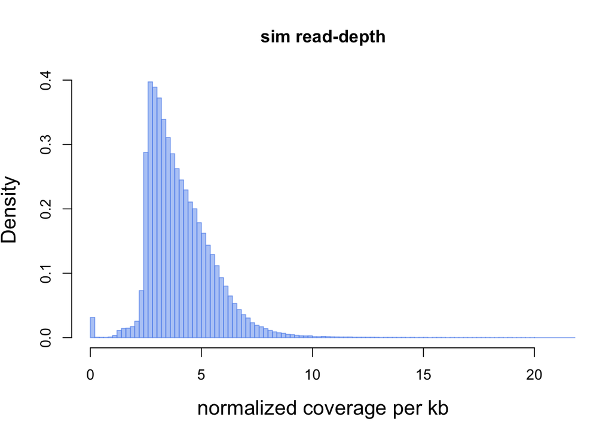

```
## [1] 1
## [1] 2.5
```

```
## [1] 1
## [1] 2.6
```

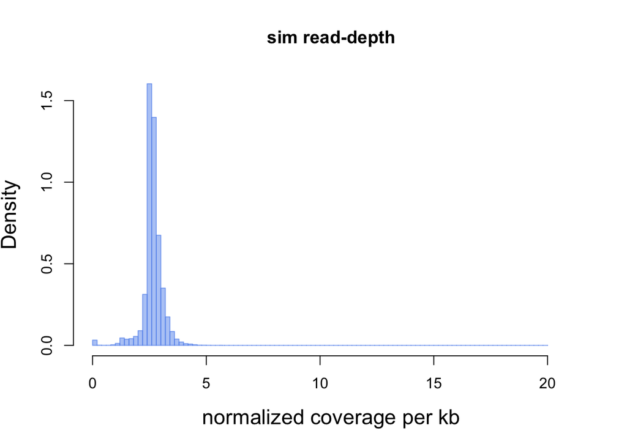

```
## [1] 1
## [1] 2.7
```

```
## [1] 1
## [1] 2.8
```

```
## [1] 1
## [1] 2.9
```

```
## [1] 1
## [1] 3
```

```
## [1] 1
## [1] 3.1
```

```
## [1] 1
## [1] 3.2
```

```
## [1] 1
## [1] 3.3
```

```
## [1] 1
## [1] 3.4
```

```
## [1] 1
## [1] 3.5
```

```
## [1] 1
## [1] 3.6
```

```
## [1] 1
## [1] 3.7
```

```
## [1] 1
## [1] 3.8
```

```
## [1] 1
## [1] 3.9
```

```
## [1] 1
## [1] 4
```

```
## [1] 1
## [1] 4.1
```

```
## [1] 1
## [1] 4.2
```

```
## [1] 1
## [1] 4.3
```

```
## [1] 1
## [1] 4.4
```

```
## [1] 1
## [1] 4.5
```

```
## [1] 1
## [1] 4.6
```

```
## [1] 1
## [1] 4.7
```

```
## [1] 1
## [1] 4.8
```

```
## [1] 1
## [1] 4.9
```

```
## [1] 1
## [1] 5
```

```
## [1] 1
## [1] 5.1
```

```
## [1] 1
## [1] 5.2
```

```
## [1] 1
## [1] 5.3
```

```
## [1] 1
## [1] 5.4
```

```
## [1] 1
## [1] 5.5
```

```
## [1] 1
## [1] 5.6
```

```
## [1] 1
## [1] 5.7
```

```
## [1] 1
## [1] 5.8
```

```
## [1] 1
## [1] 5.9
```

```
## [1] 1
## [1] 6
```

```
## [1] 1
## [1] 6.1
```

```
## [1] 1
## [1] 6.2
```

```
## [1] 1
## [1] 6.3
```

```
## [1] 1
## [1] 6.4
```

```
## [1] 1
## [1] 6.5
```

```
## [1] 1
## [1] 6.6
```

```
## [1] 1.1
## [1] 2.5
```

```
## [1] 1.1
## [1] 2.6
```

```
## [1] 1.1
## [1] 2.7
```

```
## [1] 1.1
## [1] 2.8
```

```
## [1] 1.1
## [1] 2.9
```

```
## [1] 1.1
## [1] 3
```

```
## [1] 1.1
## [1] 3.1
```

```
## [1] 1.1
## [1] 3.2
```

```
## [1] 1.1
## [1] 3.3
```

```
## [1] 1.1
## [1] 3.4
```

```
## [1] 1.1
## [1] 3.5
```

```
## [1] 1.1
## [1] 3.6
```

```
## [1] 1.1
## [1] 3.7
```

```
## [1] 1.1
## [1] 3.8
```

```
## [1] 1.1
## [1] 3.9
```

```
## [1] 1.1
## [1] 4
```

```
## [1] 1.1
## [1] 4.1
```

```
## [1] 1.1
## [1] 4.2
```

```
## [1] 1.1
## [1] 4.3
```

```
## [1] 1.1
## [1] 4.4
```

```
## [1] 1.1
## [1] 4.5
```

```
## [1] 1.1
## [1] 4.6
```

```
## [1] 1.1
## [1] 4.7
```

```
## [1] 1.1
## [1] 4.8
```

```
## [1] 1.1
## [1] 4.9
```

```
## [1] 1.1
## [1] 5
```

```
## [1] 1.1
## [1] 5.1
```

```
## [1] 1.1
## [1] 5.2
```

```
## [1] 1.1
## [1] 5.3
```

```
## [1] 1.1
## [1] 5.4
```

```
## [1] 1.1
## [1] 5.5
```

```
## [1] 1.1
## [1] 5.6
```

```
## [1] 1.1
## [1] 5.7
```

```
## [1] 1.1
## [1] 5.8
```

```
## [1] 1.1
## [1] 5.9
```

```
## [1] 1.1
## [1] 6
```

```
## [1] 1.1
## [1] 6.1
```

```
## [1] 1.1
## [1] 6.2
```

```
## [1] 1.1
## [1] 6.3
```

```
## [1] 1.1
## [1] 6.4
```

```
## [1] 1.1
## [1] 6.5
```

```
## [1] 1.1
## [1] 6.6
```

```
## [1] 1.2
## [1] 2.5
```

```
## [1] 1.2
## [1] 2.6
```

```
## [1] 1.2
## [1] 2.7
```

```
## [1] 1.2
## [1] 2.8
```

```
## [1] 1.2
## [1] 2.9
```

```
## [1] 1.2
## [1] 3
```

```
## [1] 1.2
## [1] 3.1
```

```
## [1] 1.2
## [1] 3.2
```

```
## [1] 1.2
## [1] 3.3
```

```
## [1] 1.2
## [1] 3.4
```

```
## [1] 1.2
## [1] 3.5
```

```
## [1] 1.2
## [1] 3.6
```

```
## [1] 1.2
## [1] 3.7
```

```
## [1] 1.2
## [1] 3.8
```

```
## [1] 1.2
## [1] 3.9
```

```
## [1] 1.2
## [1] 4
```

```
## [1] 1.2
## [1] 4.1
```

```
## [1] 1.2
## [1] 4.2
```

```
## [1] 1.2
## [1] 4.3
```

```
## [1] 1.2
## [1] 4.4
```

```
## [1] 1.2
## [1] 4.5
```

```
## [1] 1.2
## [1] 4.6
```

```
## [1] 1.2
## [1] 4.7
```

```
## [1] 1.2
## [1] 4.8
```

```
## [1] 1.2
## [1] 4.9
```

```
## [1] 1.2
## [1] 5
```

```
## [1] 1.2
## [1] 5.1
```

```
## [1] 1.2
## [1] 5.2
```

```
## [1] 1.2
## [1] 5.3
```

```
## [1] 1.2
## [1] 5.4
```

```
## [1] 1.2
## [1] 5.5
```

```
## [1] 1.2
## [1] 5.6
```

```
## [1] 1.2
## [1] 5.7
```

```
## [1] 1.2
## [1] 5.8
```

```
## [1] 1.2
## [1] 5.9
```

```
## [1] 1.2
## [1] 6
```

```
## [1] 1.2
## [1] 6.1
```

```
## [1] 1.2
## [1] 6.2
```

```
## [1] 1.2
## [1] 6.3
```

```
## [1] 1.2
## [1] 6.4
```

```
## [1] 1.2
## [1] 6.5
```

```
## [1] 1.2
## [1] 6.6
```

```
## [1] 1.3
## [1] 2.5
```

```
## [1] 1.3
## [1] 2.6
```

```
## [1] 1.3
## [1] 2.7
```

```
## [1] 1.3
## [1] 2.8
```

```
## [1] 1.3
## [1] 2.9
```

```
## [1] 1.3
## [1] 3
```

```
## [1] 1.3
## [1] 3.1
```

```
## [1] 1.3
## [1] 3.2
```

```
## [1] 1.3
## [1] 3.3
```

```
## [1] 1.3
## [1] 3.4
```

```
## [1] 1.3
## [1] 3.5
```

```
## [1] 1.3
## [1] 3.6
```

```
## [1] 1.3
## [1] 3.7
```

```
## [1] 1.3
## [1] 3.8
```

```
## [1] 1.3
## [1] 3.9
```

```
## [1] 1.3
## [1] 4
```

```
## [1] 1.3
## [1] 4.1
```

```
## [1] 1.3
## [1] 4.2
```

```
## [1] 1.3
## [1] 4.3
```

```
## [1] 1.3
## [1] 4.4
```

```
## [1] 1.3
## [1] 4.5
```

```
## [1] 1.3
## [1] 4.6
```

```
## [1] 1.3
## [1] 4.7
```

```
## [1] 1.3
## [1] 4.8
```

```
## [1] 1.3
## [1] 4.9
```

```
## [1] 1.3
## [1] 5
```

```
## [1] 1.3
## [1] 5.1
```

```
## [1] 1.3
## [1] 5.2
```

```
## [1] 1.3
## [1] 5.3
```

```
## [1] 1.3
## [1] 5.4
```

```
## [1] 1.3
## [1] 5.5
```

```
## [1] 1.3
## [1] 5.6
```

```
## [1] 1.3
## [1] 5.7
```

```
## [1] 1.3
## [1] 5.8
```

```
## [1] 1.3
## [1] 5.9
```

```
## [1] 1.3
## [1] 6
```

```
## [1] 1.3
## [1] 6.1
```

```
## [1] 1.3
## [1] 6.2
```

```
## [1] 1.3
## [1] 6.3
```

```
## [1] 1.3
## [1] 6.4
```

```
## [1] 1.3
## [1] 6.5
```

```
## [1] 1.3
## [1] 6.6
```

```
## [1] 1.4
## [1] 2.5
```

```
## [1] 1.4
## [1] 2.6
```

```
## [1] 1.4
## [1] 2.7
```

```
## [1] 1.4
## [1] 2.8
```

```
## [1] 1.4
## [1] 2.9
```

```
## [1] 1.4
## [1] 3
```

```
## [1] 1.4
## [1] 3.1
```

```
## [1] 1.4
## [1] 3.2
```

```
## [1] 1.4
## [1] 3.3
```

```
## [1] 1.4
## [1] 3.4
```

```
## [1] 1.4
## [1] 3.5
```

```
## [1] 1.4
## [1] 3.6
```

```
## [1] 1.4
## [1] 3.7
```

```
## [1] 1.4
## [1] 3.8
```

```
## [1] 1.4
## [1] 3.9
```

```
## [1] 1.4
## [1] 4
```

```
## [1] 1.4
## [1] 4.1
```

```
## [1] 1.4
## [1] 4.2
```

```
## [1] 1.4
## [1] 4.3
```

```
## [1] 1.4
## [1] 4.4
```

```
## [1] 1.4
## [1] 4.5
```

```
## [1] 1.4
## [1] 4.6
```

```
## [1] 1.4
## [1] 4.7
```

```
## [1] 1.4
## [1] 4.8
```

```
## [1] 1.4
## [1] 4.9
```

```
## [1] 1.4
## [1] 5
```

```
## [1] 1.4
## [1] 5.1
```

```
## [1] 1.4
## [1] 5.2
```

```
## [1] 1.4
## [1] 5.3
```

```
## [1] 1.4
## [1] 5.4
```

```
## [1] 1.4
## [1] 5.5
```

```
## [1] 1.4
## [1] 5.6
```

```
## [1] 1.4
## [1] 5.7
```

```
## [1] 1.4
## [1] 5.8
```

```
## [1] 1.4
## [1] 5.9
```

```
## [1] 1.4
## [1] 6
```

```
## [1] 1.4
## [1] 6.1
```

```
## [1] 1.4
## [1] 6.2
```

```
## [1] 1.4
## [1] 6.3
```

```
## [1] 1.4
## [1] 6.4
```

```
## [1] 1.4
## [1] 6.5
```

```
## [1] 1.4
## [1] 6.6
```

```
## [1] 1.5
## [1] 2.5
```

```
## [1] 1.5
## [1] 2.6
```

```
## [1] 1.5
## [1] 2.7
```

```
## [1] 1.5
## [1] 2.8
```

```
## [1] 1.5
## [1] 2.9
```

```
## [1] 1.5
## [1] 3
```

```
## [1] 1.5
## [1] 3.1
```

```
## [1] 1.5
## [1] 3.2
```

```
## [1] 1.5
## [1] 3.3
```

```
## [1] 1.5
## [1] 3.4
```

```
## [1] 1.5
## [1] 3.5
```

```
## [1] 1.5
## [1] 3.6
```

```
## [1] 1.5
## [1] 3.7
```

```
## [1] 1.5
## [1] 3.8
```

```
## [1] 1.5
## [1] 3.9
```

```
## [1] 1.5
## [1] 4
```

```
## [1] 1.5
## [1] 4.1
```

```
## [1] 1.5
## [1] 4.2
```

```
## [1] 1.5
## [1] 4.3
```

```
## [1] 1.5
## [1] 4.4
```

```
## [1] 1.5
## [1] 4.5
```

```
## [1] 1.5
## [1] 4.6
```

```
## [1] 1.5
## [1] 4.7
```

```
## [1] 1.5
## [1] 4.8
```

```
## [1] 1.5
## [1] 4.9
```

```
## [1] 1.5
## [1] 5
```

```
## [1] 1.5
## [1] 5.1
```

```
## [1] 1.5
## [1] 5.2
```

```
## [1] 1.5
## [1] 5.3
```

```
## [1] 1.5
## [1] 5.4
```

```
## [1] 1.5
## [1] 5.5
```

```
## [1] 1.5
## [1] 5.6
```

```
## [1] 1.5
## [1] 5.7
```

```
## [1] 1.5
## [1] 5.8
```

```
## [1] 1.5
## [1] 5.9
```

```
## [1] 1.5
## [1] 6
```

```
## [1] 1.5
## [1] 6.1
```

```
## [1] 1.5
## [1] 6.2
```

```
## [1] 1.5
## [1] 6.3
```

```
## [1] 1.5
## [1] 6.4
```

```
## [1] 1.5
## [1] 6.5
```

```
## [1] 1.5
## [1] 6.6
```

```
## [1] 1.6
## [1] 2.5
```

```
## [1] 1.6
## [1] 2.6
```

```
## [1] 1.6
## [1] 2.7
```

```
## [1] 1.6
## [1] 2.8
```

```
## [1] 1.6
## [1] 2.9
```

```
## [1] 1.6
## [1] 3
```

```
## [1] 1.6
## [1] 3.1
```

```
## [1] 1.6
## [1] 3.2
```

```
## [1] 1.6
## [1] 3.3
```

```
## [1] 1.6
## [1] 3.4
```

```
## [1] 1.6
## [1] 3.5
```

```
## [1] 1.6
## [1] 3.6
```

```
## [1] 1.6
## [1] 3.7
```

```
## [1] 1.6
## [1] 3.8
```

```
## [1] 1.6
## [1] 3.9
```

```
## [1] 1.6
## [1] 4
```

```
## [1] 1.6
## [1] 4.1
```

```
## [1] 1.6
## [1] 4.2
```

```
## [1] 1.6
## [1] 4.3
```

```
## [1] 1.6
## [1] 4.4
```

```
## [1] 1.6
## [1] 4.5
```

```
## [1] 1.6
## [1] 4.6
```

```
## [1] 1.6
## [1] 4.7
```

```
## [1] 1.6
## [1] 4.8
```

```
## [1] 1.6
## [1] 4.9
```

```
## [1] 1.6
## [1] 5
```

```
## [1] 1.6
## [1] 5.1
```

```
## [1] 1.6
## [1] 5.2
```

```
## [1] 1.6
## [1] 5.3
```

```
## [1] 1.6
## [1] 5.4
```

```
## [1] 1.6
## [1] 5.5
```

```
## [1] 1.6
## [1] 5.6
```

```
## [1] 1.6
## [1] 5.7
```

```
## [1] 1.6
## [1] 5.8
```

```
## [1] 1.6
## [1] 5.9
```

```
## [1] 1.6
## [1] 6
```

```
## [1] 1.6
## [1] 6.1
```

```
## [1] 1.6
## [1] 6.2
```

```
## [1] 1.6
## [1] 6.3
```

```
## [1] 1.6
## [1] 6.4
```

```
## [1] 1.6
## [1] 6.5
```

```
## [1] 1.6
## [1] 6.6
```

```
## [1] 1.7
## [1] 2.5
```

```
## [1] 1.7
## [1] 2.6
```

```
## [1] 1.7
## [1] 2.7
```

```
## [1] 1.7
## [1] 2.8
```

```
## [1] 1.7
## [1] 2.9
```

```
## [1] 1.7
## [1] 3
```

```
## [1] 1.7
## [1] 3.1
```

```
## [1] 1.7
## [1] 3.2
```

```
## [1] 1.7
## [1] 3.3
```

```
## [1] 1.7
## [1] 3.4
```

```
## [1] 1.7
## [1] 3.5
```

```
## [1] 1.7
## [1] 3.6
```

```
## [1] 1.7
## [1] 3.7
```

```
## [1] 1.7
## [1] 3.8
```

```
## [1] 1.7
## [1] 3.9
```

```
## [1] 1.7
## [1] 4
```

```
## [1] 1.7
## [1] 4.1
```

```
## [1] 1.7
## [1] 4.2
```

```
## [1] 1.7
## [1] 4.3
```

```
## [1] 1.7
## [1] 4.4
```

```
## [1] 1.7
## [1] 4.5
```

```
## [1] 1.7
## [1] 4.6
```

```
## [1] 1.7
## [1] 4.7
```

```
## [1] 1.7
## [1] 4.8
```

```
## [1] 1.7
## [1] 4.9
```

```
## [1] 1.7
## [1] 5
```

```
## [1] 1.7
## [1] 5.1
```

```
## [1] 1.7
## [1] 5.2
```

```
## [1] 1.7
## [1] 5.3
```

```
## [1] 1.7
## [1] 5.4
```

```
## [1] 1.7
## [1] 5.5
```

```
## [1] 1.7
## [1] 5.6
```

```
## [1] 1.7
## [1] 5.7
```

```
## [1] 1.7
## [1] 5.8
```

```
## [1] 1.7
## [1] 5.9
```

```
## [1] 1.7
## [1] 6
```

```
## [1] 1.7
## [1] 6.1
```

```
## [1] 1.7
## [1] 6.2
```

```
## [1] 1.7
## [1] 6.3
```

```
## [1] 1.7
## [1] 6.4
```

```
## [1] 1.7
## [1] 6.5
```

```
## [1] 1.7
## [1] 6.6
```

```
## [1] 1.8
## [1] 2.5
```

```
## [1] 1.8
## [1] 2.6
```

```
## [1] 1.8
## [1] 2.7
```

```
## [1] 1.8
## [1] 2.8
```

```
## [1] 1.8
## [1] 2.9
```

```
## [1] 1.8
## [1] 3
```

```
## [1] 1.8
## [1] 3.1
```

```
## [1] 1.8
## [1] 3.2
```

```
## [1] 1.8
## [1] 3.3
```

```
## [1] 1.8
## [1] 3.4
```

```
## [1] 1.8
## [1] 3.5
```

```
## [1] 1.8
## [1] 3.6
```

```
## [1] 1.8
## [1] 3.7
```

```
## [1] 1.8
## [1] 3.8
```

```
## [1] 1.8
## [1] 3.9
```

```
## [1] 1.8
## [1] 4
```

```
## [1] 1.8
## [1] 4.1
```

```
## [1] 1.8
## [1] 4.2
```

```
## [1] 1.8
## [1] 4.3
```

```
## [1] 1.8
## [1] 4.4
```

```
## [1] 1.8
## [1] 4.5
```

```
## [1] 1.8
## [1] 4.6
```

```
## [1] 1.8
## [1] 4.7
```

```
## [1] 1.8
## [1] 4.8
```

```
## [1] 1.8
## [1] 4.9
```

```
## [1] 1.8
## [1] 5
```

```
## [1] 1.8
## [1] 5.1
```

```
## [1] 1.8
## [1] 5.2
```

```
## [1] 1.8
## [1] 5.3
```

```
## [1] 1.8
## [1] 5.4
```

```
## [1] 1.8
## [1] 5.5
```

```
## [1] 1.8
## [1] 5.6
```

```
## [1] 1.8
## [1] 5.7
```

```
## [1] 1.8
## [1] 5.8
```

```
## [1] 1.8
## [1] 5.9
```

```
## [1] 1.8
## [1] 6
```

```
## [1] 1.8
## [1] 6.1
```

```
## [1] 1.8
## [1] 6.2
```

```
## [1] 1.8
## [1] 6.3
```

```
## [1] 1.8
## [1] 6.4
```

```
## [1] 1.8
## [1] 6.5
```

```
## [1] 1.8
## [1] 6.6
```

```
## [1] 1.9
## [1] 2.5
```

```
## [1] 1.9
## [1] 2.6
```

```
## [1] 1.9
## [1] 2.7
```

```
## [1] 1.9
## [1] 2.8
```

```
## [1] 1.9
## [1] 2.9
```

```
## [1] 1.9
## [1] 3
```

```
## [1] 1.9
## [1] 3.1
```

```
## [1] 1.9
## [1] 3.2
```

```
## [1] 1.9
## [1] 3.3
```

```
## [1] 1.9
## [1] 3.4
```

```
## [1] 1.9
## [1] 3.5
```

```
## [1] 1.9
## [1] 3.6
```

```
## [1] 1.9
## [1] 3.7
```

```
## [1] 1.9
## [1] 3.8
```

```
## [1] 1.9
## [1] 3.9
```

```
## [1] 1.9
## [1] 4
```

```
## [1] 1.9
## [1] 4.1
```

```
## [1] 1.9
## [1] 4.2
```

```
## [1] 1.9
## [1] 4.3
```

```
## [1] 1.9
## [1] 4.4
```

```
## [1] 1.9
## [1] 4.5
```

```
## [1] 1.9
## [1] 4.6
```

```
## [1] 1.9
## [1] 4.7
```

```
## [1] 1.9
## [1] 4.8
```

```
## [1] 1.9
## [1] 4.9
```

```
## [1] 1.9
## [1] 5
```

```
## [1] 1.9
## [1] 5.1
```

```
## [1] 1.9
## [1] 5.2
```

```
## [1] 1.9
## [1] 5.3
```

```
## [1] 1.9
## [1] 5.4
```

```
## [1] 1.9
## [1] 5.5
```

```
## [1] 1.9
## [1] 5.6
```

```
## [1] 1.9
## [1] 5.7
```

```
## [1] 1.9
## [1] 5.8
```

```
## [1] 1.9
## [1] 5.9
```

```
## [1] 1.9
## [1] 6
```

```
## [1] 1.9
## [1] 6.1
```

```
## [1] 1.9
## [1] 6.2
```

```
## [1] 1.9
## [1] 6.3
```

```
## [1] 1.9
## [1] 6.4
```

```
## [1] 1.9
## [1] 6.5
```

```
## [1] 1.9
## [1] 6.6
```

```
## [1] 2
## [1] 2.5
```

```
## [1] 2
## [1] 2.6
```

```
## [1] 2
## [1] 2.7
```

```
## [1] 2
## [1] 2.8
```

```
## [1] 2
## [1] 2.9
```

```
## [1] 2
## [1] 3
```

```
## [1] 2
## [1] 3.1
```

```
## [1] 2
## [1] 3.2
```

```
## [1] 2
## [1] 3.3
```

```
## [1] 2
## [1] 3.4
```

```
## [1] 2
## [1] 3.5
```

```
## [1] 2
## [1] 3.6
```

```
## [1] 2
## [1] 3.7
```

```
## [1] 2
## [1] 3.8
```

```
## [1] 2
## [1] 3.9
```

```
## [1] 2
## [1] 4
```

```
## [1] 2
## [1] 4.1
```

```
## [1] 2
## [1] 4.2
```

```
## [1] 2
## [1] 4.3
```

```
## [1] 2
## [1] 4.4
```

```
## [1] 2
## [1] 4.5
```

```
## [1] 2
## [1] 4.6
```

```
## [1] 2
## [1] 4.7
```

```
## [1] 2
## [1] 4.8
```

```
## [1] 2
## [1] 4.9
```

```
## [1] 2
## [1] 5
```

```
## [1] 2
## [1] 5.1
```

```
## [1] 2
## [1] 5.2
```

```
## [1] 2
## [1] 5.3
```

```
## [1] 2
## [1] 5.4
```

```
## [1] 2
## [1] 5.5
```

```
## [1] 2
## [1] 5.6
```

```
## [1] 2
## [1] 5.7
```

```
## [1] 2
## [1] 5.8
```

```
## [1] 2
## [1] 5.9
```

```
## [1] 2
## [1] 6
```

```
## [1] 2
## [1] 6.1
```

```
## [1] 2
## [1] 6.2
```

```
## [1] 2
## [1] 6.3
```

```
## [1] 2
## [1] 6.4
```

```
## [1] 2
## [1] 6.5
```

```
## [1] 2
## [1] 6.6
```

```
## [1] 2.1
## [1] 2.5
```

```
## [1] 2.1
## [1] 2.6
```

```
## [1] 2.1
## [1] 2.7
```

```
## [1] 2.1
## [1] 2.8
```

```
## [1] 2.1
## [1] 2.9
```

```
## [1] 2.1
## [1] 3
```

```
## [1] 2.1
## [1] 3.1
```

```
## [1] 2.1
## [1] 3.2
```

```
## [1] 2.1
## [1] 3.3
```

```
## [1] 2.1
## [1] 3.4
```

```
## [1] 2.1
## [1] 3.5
```

```
## [1] 2.1
## [1] 3.6
```

```
## [1] 2.1
## [1] 3.7
```

```
## [1] 2.1
## [1] 3.8
```

```
## [1] 2.1
## [1] 3.9
```

```
## [1] 2.1
## [1] 4
```

```
## [1] 2.1
## [1] 4.1
```

```
## [1] 2.1
## [1] 4.2
```

```
## [1] 2.1
## [1] 4.3
```

```
## [1] 2.1
## [1] 4.4
```

```
## [1] 2.1
## [1] 4.5
```

```
## [1] 2.1
## [1] 4.6
```

```
## [1] 2.1
## [1] 4.7
```

```
## [1] 2.1
## [1] 4.8
```

```
## [1] 2.1
## [1] 4.9
```

```
## [1] 2.1
## [1] 5
```

```
## [1] 2.1
## [1] 5.1
```

```
## [1] 2.1
## [1] 5.2
```

```
## [1] 2.1
## [1] 5.3
```

```
## [1] 2.1
## [1] 5.4
```

```
## [1] 2.1
## [1] 5.5
```

```
## [1] 2.1
## [1] 5.6
```

```
## [1] 2.1
## [1] 5.7
```

```
## [1] 2.1
## [1] 5.8
```

```
## [1] 2.1
## [1] 5.9
```

```
## [1] 2.1
## [1] 6
```

```
## [1] 2.1
## [1] 6.1
```

```
## [1] 2.1
## [1] 6.2
```

```
## [1] 2.1
## [1] 6.3
```

```
## [1] 2.1
## [1] 6.4
```

```
## [1] 2.1
## [1] 6.5
```

```
## [1] 2.1
## [1] 6.6
```

```
## [1] 2.2
## [1] 2.5
```

```
## [1] 2.2
## [1] 2.6
```

```
## [1] 2.2
## [1] 2.7
```

```
## [1] 2.2
## [1] 2.8
```

```
## [1] 2.2
## [1] 2.9
```

```
## [1] 2.2
## [1] 3
```

```
## [1] 2.2
## [1] 3.1
```

```
## [1] 2.2
## [1] 3.2
```

```
## [1] 2.2
## [1] 3.3
```

```
## [1] 2.2
## [1] 3.4
```

```
## [1] 2.2
## [1] 3.5
```

```
## [1] 2.2
## [1] 3.6
```

```
## [1] 2.2
## [1] 3.7
```

```
## [1] 2.2
## [1] 3.8
```

```
## [1] 2.2
## [1] 3.9
```

```
## [1] 2.2
## [1] 4
```

```
## [1] 2.2
## [1] 4.1
```

```
## [1] 2.2
## [1] 4.2
```

```
## [1] 2.2
## [1] 4.3
```

```
## [1] 2.2
## [1] 4.4
```

```
## [1] 2.2
## [1] 4.5
```

```
## [1] 2.2
## [1] 4.6
```

```
## [1] 2.2
## [1] 4.7
```

```
## [1] 2.2
## [1] 4.8
```

```
## [1] 2.2
## [1] 4.9
```

```
## [1] 2.2
## [1] 5
```

```
## [1] 2.2
## [1] 5.1
```

```
## [1] 2.2
## [1] 5.2
```

```
## [1] 2.2
## [1] 5.3
```

```
## [1] 2.2
## [1] 5.4
```

```
## [1] 2.2
## [1] 5.5
```

```
## [1] 2.2
## [1] 5.6
```

```
## [1] 2.2
## [1] 5.7
```

```
## [1] 2.2
## [1] 5.8
```

```
## [1] 2.2
## [1] 5.9
```

```
## [1] 2.2
## [1] 6
```

```
## [1] 2.2
## [1] 6.1
```

```
## [1] 2.2
## [1] 6.2
```

```
## [1] 2.2
## [1] 6.3
```

```
## [1] 2.2
## [1] 6.4
```

```
## [1] 2.2
## [1] 6.5
```

```
## [1] 2.2
## [1] 6.6
```

```
## [1] 2.3
## [1] 2.5
```

```
## [1] 2.3
## [1] 2.6
```

```
## [1] 2.3
## [1] 2.7
```

```
## [1] 2.3
## [1] 2.8
```

```
## [1] 2.3
## [1] 2.9
```

```
## [1] 2.3
## [1] 3
```

```
## [1] 2.3
## [1] 3.1
```

```
## [1] 2.3
## [1] 3.2
```

```
## [1] 2.3
## [1] 3.3
```

```
## [1] 2.3
## [1] 3.4
```

```
## [1] 2.3
## [1] 3.5
```

```
## [1] 2.3
## [1] 3.6
```

```
## [1] 2.3
## [1] 3.7
```

```
## [1] 2.3
## [1] 3.8
```

```
## [1] 2.3
## [1] 3.9
```

```
## [1] 2.3
## [1] 4
```

```
## [1] 2.3
## [1] 4.1
```

```
## [1] 2.3
## [1] 4.2
```

```
## [1] 2.3
## [1] 4.3
```

```
## [1] 2.3
## [1] 4.4
```

```
## [1] 2.3
## [1] 4.5
```

```
## [1] 2.3
## [1] 4.6
```

```
## [1] 2.3
## [1] 4.7
```

```
## [1] 2.3
## [1] 4.8
```

```
## [1] 2.3
## [1] 4.9
```

```
## [1] 2.3
## [1] 5
```

```
## [1] 2.3
## [1] 5.1
```

```
## [1] 2.3
## [1] 5.2
```

```
## [1] 2.3
## [1] 5.3
```

```
## [1] 2.3
## [1] 5.4
```

```
## [1] 2.3
## [1] 5.5
```

```
## [1] 2.3
## [1] 5.6
```

```
## [1] 2.3
## [1] 5.7
```

```
## [1] 2.3
## [1] 5.8
```

```
## [1] 2.3
## [1] 5.9
```

```
## [1] 2.3
## [1] 6
```

```
## [1] 2.3
## [1] 6.1
```

```
## [1] 2.3
## [1] 6.2
```

```
## [1] 2.3
## [1] 6.3
```

```
## [1] 2.3
## [1] 6.4
```

```
## [1] 2.3
## [1] 6.5
```

```
## [1] 2.3
## [1] 6.6
```

```
## [1] 2.4
## [1] 2.5
```

```
## [1] 2.4
## [1] 2.6
```

```
## [1] 2.4
## [1] 2.7
```

```
## [1] 2.4
## [1] 2.8
```

```
## [1] 2.4
## [1] 2.9
```

```
## [1] 2.4
## [1] 3
```

```
## [1] 2.4
## [1] 3.1
```

```
## [1] 2.4
## [1] 3.2
```

```
## [1] 2.4
## [1] 3.3
```

```
## [1] 2.4
## [1] 3.4
```

```
## [1] 2.4
## [1] 3.5
```

```
## [1] 2.4
## [1] 3.6
```

```
## [1] 2.4
## [1] 3.7
```

```
## [1] 2.4
## [1] 3.8
```

```
## [1] 2.4
## [1] 3.9
```

```
## [1] 2.4
## [1] 4
```

```
## [1] 2.4
## [1] 4.1
```

```
## [1] 2.4
## [1] 4.2
```

```
## [1] 2.4
## [1] 4.3
```

```
## [1] 2.4
## [1] 4.4
```

```
## [1] 2.4
## [1] 4.5
```

```
## [1] 2.4
## [1] 4.6
```

```
## [1] 2.4
## [1] 4.7
```

```
## [1] 2.4
## [1] 4.8
```

```
## [1] 2.4
## [1] 4.9
```

```
## [1] 2.4
## [1] 5
```

```
## [1] 2.4
## [1] 5.1
```

```
## [1] 2.4
## [1] 5.2
```

```
## [1] 2.4
## [1] 5.3
```

```
## [1] 2.4
## [1] 5.4
```

```
## [1] 2.4
## [1] 5.5
```

```
## [1] 2.4
## [1] 5.6
```

```
## [1] 2.4
## [1] 5.7
```

```
## [1] 2.4
## [1] 5.8
```

```
## [1] 2.4
## [1] 5.9
```

```
## [1] 2.4
## [1] 6
```

```
## [1] 2.4
## [1] 6.1
```

```
## [1] 2.4
## [1] 6.2
```

```
## [1] 2.4
## [1] 6.3
```

```
## [1] 2.4
## [1] 6.4
```

```
## [1] 2.4
## [1] 6.5
```

```
## [1] 2.4
## [1] 6.6
```

```r
seqI<-seq(iStart,iEnd,by=by)
seqJ<-seq(jStart,jEnd,by=by)
for ( i in 1:length(seq(iStart,iEnd,by=by))) {
  for ( j in 1:length(seq(jStart,jEnd,by=by))) {
  cnv.mat<-matrix(data=2,nrow=dim(simData)[1],ncol=1)
  rownames(cnv.mat)<-simData$name
  colnames(cnv.mat)<-"sim_CNV"
  #cnv.mat<-data.table<-(cnv.mat)
  simData<-subset(simData,select=c("name","sim","type", "B73.bam"))
  lims<-NULL
  stddevs<-NULL
  colnames(cnv.mat)<-NULL
  s<-"sim"
    sub.df<-subset(simData,select=c(s,"name"))
    sub.df<-data.frame(sub.df)
    # print(head(sub.df))
    hist(sub.df$sim, main =paste0(s, " read-depth"),
       xlab="normalized coverage per kb",cex.lab=1.4, breaks = c(seq(0,20,0.2),20.00001,max(sub.df$sim)),
       xlim=c(0,21), col = alpha("cornflowerblue",0.5),border=alpha("cornflowerblue",0.7))
    # calculate the ratio between sample and reference"
    ratio<-subset(sub.df,select="sim")$sim / subset(simData,select="B73.bam")$B73.bam
    ratio<-data.matrix(ratio)
    ratio<-log(ratio+0.001)
    #ratio<-log(ratio1)
    stdev<-sd(ratio)
    stddevs<-c(stddevs,stdev)
    d<-(mean(ratio)-ratio)
    limit<-seqI[i]
    print(limit)
    limitHom<-seqJ[j]
    print(limitHom)
    linePos<-mean(ratio)+(limit*stdev)
    linePosHom<-mean(ratio)+(limitHom*stdev)
    lims<-c(lims,min(mean(ratio)+linePos),abs(mean(ratio)-linePos))
    #abline(v=mean(ratio), col = "black", lwd=2, lty = "solid",lend=1)
    #turn sub.df back into a data.table
    sub.df<-data.table(sub.df,ratio)
    ratio.df<-data.table(sub.df,ratio)
    sName<-paste0(s,"_CNV")
    simData[,sName:=2,with=FALSE]
    # call down CNV
    calls<-(simData[,sName,with=FALSE])
    calls<-as.vector(as.matrix(calls))
    calls[ratio<(mean(ratio)-linePos)]<-1
    calls[ratio<(mean(ratio)-linePosHom)]<-0
    # call up CNV
    calls[ratio>(mean(ratio)+linePos)]<-3
    #attribute
    simData[,sName:=calls,with=FALSE]

#####################################################################
# Now access the heterozygous calls and compare to the simulated data
#####################################################################

    #subset to just "gene" intervals
    simData<-subset(simData,subset= type == "gene")

    calledHets<-unique(subset(simData,subset=sim_CNV == 1)$name)
    calledHomo<-unique(subset(simData,subset=sim_CNV == 0)$name)
    calledPres<-unique(subset(simData,subset=sim_CNV == 2)$name)

    ####
    # Find out the True positive Matches
    ####
    hetTrue<-calledHets %in% hets$V1
    homoTrue<-calledHomo %in% homoAbs$V1
    present<-calledPres %in% homoPres

####
# Find the false positives
####

    hetFalse<-!calledHets %in% hets$V1
    homoFalse<-!calledHomo %in% homoAbs$V1
    presentFalse<-!calledPres %in% homoPres

    ####
    # Calculate as a rate (i.e. 0 to 1)
    ####

    # now for the TP rate in het calls
    hetTPrate<-length(hetTrue[hetTrue==TRUE])/length(hets$V1)
    # now for the FP rate in het calls
    hetFPrate<-length(hetFalse[hetFalse==TRUE]) /
            ((length(hetFalse[hetFalse==TRUE]))+(length(homoPres)+length(homoAbs$V1)))

    # the same as above but for homozygote CNV calls
    homoTPrate<-length(homoTrue[homoTrue==TRUE])/length(homoAbs$V1)
    homoFPrate<-length(homoFalse[homoFalse==TRUE]) / (length(homoFalse[homoFalse==TRUE])+length(hets$V1)+ length(homoPres))

    # now the same for regular calls
    normalTPrate<-length(present[present==TRUE])/length(homoPres) #called as CNV but is normal
    normalFPrate<-length(presentFalse[presentFalse==TRUE])/
        (length(presentFalse[presentFalse==TRUE])+length(hets$V1)+length(homoAbs$V1))

  hetPrecision<-hetTPrate/(hetTPrate+hetFPrate)
  homPrecision<-homoTPrate/(homoTPrate+homoFPrate)
  normPrecision<-normalTPrate/(normalTPrate+normalFPrate)

  ratesHetTP[i,j]<-hetTPrate
  ratesHetFP[i,j]<-hetFPrate
  ratesHomoTP[i,j]<-homoTPrate
  ratesHomoFP[i,j]<-homoFPrate
  presenceTP[i,j]<-normalTPrate
  presenceFP[i,j]<-normalFPrate

  precisionHet[i,j]<-hetPrecision
  precisionHom[i,j]<-homPrecision
  precisionNorm[i,j]<-normPrecision
 }
}
```

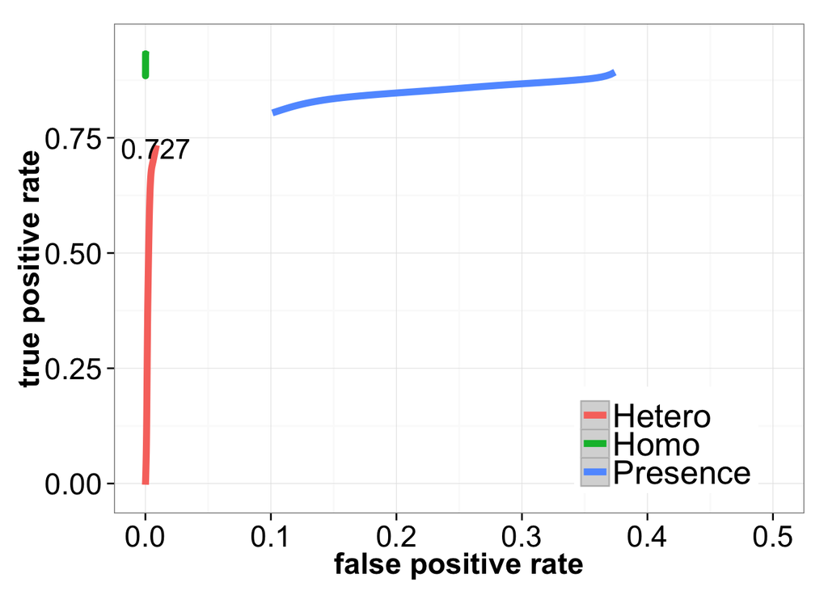

```r
####
# Set up a data.frame to plot all this complex data
####

rateTable<-rbind(cbind(melt(ratesHetTP), "type"=rep("Hetero TP rate"),"group"=rep("TP")),
cbind(melt(ratesHetFP), "type"=rep("Hetero"),"group"=rep("FP")),
cbind(melt(ratesHomoTP), "type"=rep("Homo"),"group"=rep("TP")),
cbind(melt(ratesHomoFP), "type"=rep("Homo"),"group"=rep("FP")),
cbind(melt(presenceTP), "type"=rep("Presence"),"group"=rep("TP")),
cbind(melt(presenceFP), "type"=rep("Presence"),"group"=rep("FP")) )

ggplot(rateTable,aes(x=jitter(rateTable$value[rateTable$group=="FP"]),y=rateTable$value[rateTable$group=="TP"]), factor(rateTable$type))+
  theme_bw()+
  geom_smooth(aes(colour=rateTable$type[rateTable$group=="FP"]),size=2)+
  #scale_fill_discrete("")+
  theme(axis.title=element_text(size=18,face="bold"),axis.text=element_text(size=18))+
  theme(legend.title=element_blank(), legend.position=c(0.8,0.15), legend.text=element_text(size=20))+
  xlab("false positive rate")+
  ylab("true positive rate")+
  xlim(0,0.5)+
  annotate("text",x=ratesHetFP["1","6.1"],y= ratesHetTP["1","6.1"], label=round(ratesHetTP["1","6.1"],3), size =6 )
```

```r
#simCalls<-gcNorm[,c("name","sim_CNV"), with=FALSE]
```

## Simulating Exon deletions

Firstly, choose 1000 random exons as candidates for deletion:

```
grep -v "scaffold\|Pt\|Mt" < /Users/simonrenny-byfield/maize_genome/Zea_mays.AGPv3.22.gff | grep 'exon' | gsort --random-sort | head -n 1000 >exons.1000.genes.gff
```

Next step is to generate two genomes, each with a random 500 of these genes deleted.

for the first sample:

```
bedtools maskfasta -fi /Users/simonrenny-byfield/maize_genome/Zea_mays.AGPv3.22.dna.genome.fa -fo exon.sim1_K.fa -mc K -bed <(cat exons.1000.genes.gff | gsort --random-sort | head -n 500 | tee exon.sim1.removed.genes.gff)
```

and:

```
bedtools maskfasta -fi /Users/simonrenny-byfield/maize_genome/Zea_mays.AGPv3.22.dna.genome.fa -fo exon.sim2_K.fa -mc K -bed <(cat exons.1000.genes.gff | gsort --random-sort | head -n 500 | tee exon.sim2.removed.genes.gff)
```

for the second sample.

The output needs to be cleaned up, the intervals are replaced with `K` and so we can use `sed` to filter these out using:

```
sed 's/K//g' < sim1_K.fa > sim1.fa
```

Next, we can see what genes are homozygous, and what are heterozygous for deletions amoung these two simulations. This can be done using `grep`. For example find the homozygous present using:

```
grep -F -v -f sim1.removed.genes.gff 1000.genes.gff | grep -F -v -f sim2.removed.genes.gff > sim.homo.present.gff
```

Now what about homozygous deletion:

```
grep -F -x -f sim1.removed.genes.gff sim2.removed.genes.gff > sim.homo.absent.gff
```

Now, of course, the heterozygotes:

```
grep -F -v -f sim1.removed.genes.gff sim2.removed.genes.gff > sim.hetero.gff
grep -F -v -f sim2.removed.genes.gff sim1.removed.genes.gff >> sim.hetero.gff
```

We simulate the Illumina data with a script that looks like this..

```
#!/bin/bash -l
#!/bin/bash
#SBATCH -D /group/jrigrp4/CNVsim/data/exons
#SBATCH -o /group/jrigrp4/CNVsim/logs/sim_out_log-%j.txt
#SBATCH -e /group/jrigrp4/CNVsim/logs/sim_err_log-%j.txt
#SBATCH -J sim
#SBATCH --array=0-1
#SBATCH --mem-per-cpu=3000
#SBATCH --cpus-per-task=1

##Simon Renny-Byfield, UC Davis, April 2015

files=(*.fa)

echo "Job Starting: "
date

cmd="wgsim ${files[$SLURM_ARRAY_TASK_ID]} ${files[$SLURM_ARRAY_TASK_ID]}.R1.fq ${files[$SLURM_ARRAY_TASK_ID]}.R2.fq -N 125000000 -1 100 -2 100 -S 4"
echo $cmd
eval $cmd
echo "Job Ending: "
date
```

```
#!/bin/bash -l
#!/bin/bash
#SBATCH -D /group/jrigrp4/CNVsim/data/exons/
#SBATCH -o /group/jrigrp4/CNVsim/logs/mcov_out_log-%j.txt
#SBATCH -e /group/jrigrp4/CNVsim/logs/mcov_err_log-%j.txt
#SBATCH -J multicov
#SBATCH --mem-per-cpu=12000

##Simon Renny-Byfield, UC Davis, March 2015

cmd="bedtools multicov -bams sorted.exon.sim_diploid.R1.fq.bam -bed ../../../custom_cnv/data/Zea_mays.AGPv3.22_fullModel_trimmed_sorted.bed -q 30 > sim.coverage.per.gene_no_repeats.txt"
echo $cmd
eval $cmd
```

Now do the same as above but for the exon simulations..

```r
#load in some data
setwd("/Users/simonrenny-byfield/GitHubRepos/CNVsim/data/exons")
#load("gc_Norm.RData")

temp.space <- new.env()
bar <- load("gc_Norm.RData", temp.space)
exonData<- get(bar, temp.space)

# make a matrix of 0, representing the "no evidence of change in copy-number"
simData<-subset(exonData, select=c("sim","B73.bam"))
norm.df<-fread("/Users/simonrenny-byfield/GitHubRepos/custom_cnv/data/normDepth.txt",header=TRUE)
```

```
##
Read 0.0% of 557824 rows
Read 66.3% of 557824 rows
Read 557824 rows and 29 (of 29) columns from 0.217 GB file in 00:00:05
```

```r
simData<-cbind(subset(norm.df,select=c(1:5)),simData)
simData<-subset(simData,subset=simData$B73.bam > 1)
simData<-subset(simData,subset=simData$B73.bam < 15)

simData<-subset(simData,subset=apply(subset(simData, select=c(6,7)),1,function(x) max(x)) < 100)


#first load in the heterozygotes, from the simulation
hets<-fread("exon.sim.hetero.txt", header = FALSE)
#   remove het genes that are excluded from the genotype calls
hets<-hets[hets$V1 %in% gcNorm$name]
#load in the homozygous absent
homoAbs<-fread("exon.sim.homo.absent.txt", header=FALSE)
# again remove homo genes that are excluded from the genotype calls
homoAbs<-homoAbs[homoAbs$V1 %in% gcNorm$name]

# now the genes that are not hetero or homozygous deletion in our simulation
homoPres<-unique(subset(simData,subset=!name %in% hets$V1 & !name %in% homoAbs$V1 )$name)

#set up some matrices to handle the rate data
by=0.1
iStart<-1
iEnd<-2.4
jStart<-2.5
jEnd<-6.6
ratesHetTP<-matrix(nrow=length(seq(iStart,iEnd,by=by)),ncol=length(seq(jStart,jEnd,by=by)),
              dimnames=list(seq(iStart,iEnd,by=by),seq(jStart,jEnd,by=by)))
ratesHetFP<-ratesHetTP
ratesHomoTP<-ratesHetTP
ratesHomoFP<-ratesHetTP
presenceTP<-ratesHetTP
presenceFP<-ratesHetTP
precisionHet<-ratesHetTP
precisionHom<-ratesHetTP
precisionNorm<-ratesHetTP
```

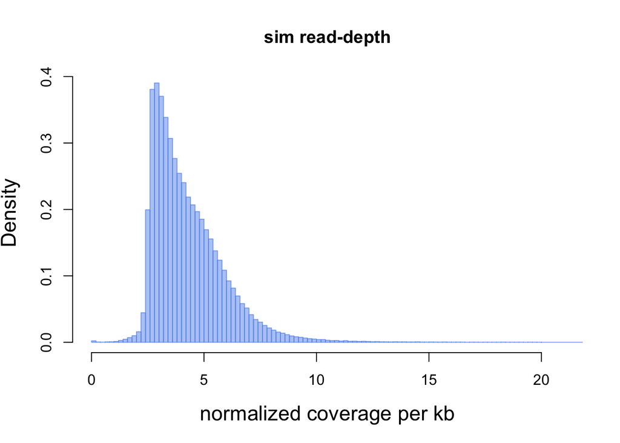

```
## [1] 1
## [1] 2.5
```

```
## [1] 1
## [1] 2.6
```

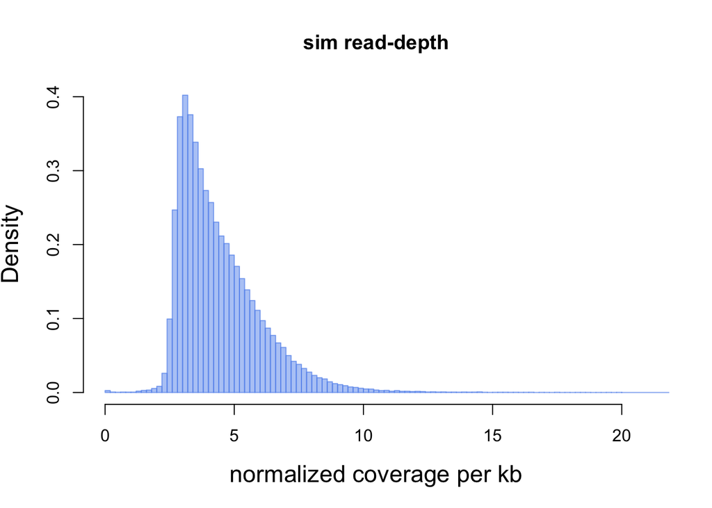

```
## [1] 1
## [1] 2.7
```

```
## [1] 1
## [1] 2.8
```

```
## [1] 1
## [1] 2.9
```

```
## [1] 1
## [1] 3
```

```
## [1] 1
## [1] 3.1
```

```
## [1] 1
## [1] 3.2
```

```
## [1] 1
## [1] 3.3
```

```
## [1] 1
## [1] 3.4
```

```
## [1] 1
## [1] 3.5
```

```
## [1] 1
## [1] 3.6
```

```
## [1] 1
## [1] 3.7
```

```
## [1] 1
## [1] 3.8
```

```
## [1] 1
## [1] 3.9
```

```
## [1] 1
## [1] 4
```

```
## [1] 1
## [1] 4.1
```

```
## [1] 1
## [1] 4.2
```

```
## [1] 1
## [1] 4.3
```

```
## [1] 1
## [1] 4.4
```

```
## [1] 1
## [1] 4.5
```

```
## [1] 1
## [1] 4.6
```

```
## [1] 1
## [1] 4.7
```

```
## [1] 1
## [1] 4.8
```

```
## [1] 1
## [1] 4.9
```

```
## [1] 1
## [1] 5
```

```
## [1] 1
## [1] 5.1
```

```
## [1] 1
## [1] 5.2
```

```
## [1] 1
## [1] 5.3
```

```
## [1] 1
## [1] 5.4
```

```
## [1] 1
## [1] 5.5
```

```
## [1] 1
## [1] 5.6
```

```
## [1] 1
## [1] 5.7
```

```
## [1] 1
## [1] 5.8
```

```
## [1] 1
## [1] 5.9
```

```
## [1] 1
## [1] 6
```

```
## [1] 1
## [1] 6.1
```

```
## [1] 1
## [1] 6.2
```

```
## [1] 1
## [1] 6.3
```

```
## [1] 1
## [1] 6.4
```

```
## [1] 1
## [1] 6.5
```

```
## [1] 1
## [1] 6.6
```

```
## [1] 1.1
## [1] 2.5
```

```
## [1] 1.1
## [1] 2.6
```

```
## [1] 1.1
## [1] 2.7
```

```
## [1] 1.1
## [1] 2.8
```

```
## [1] 1.1
## [1] 2.9
```

```
## [1] 1.1
## [1] 3
```

```
## [1] 1.1
## [1] 3.1
```

```
## [1] 1.1
## [1] 3.2
```

```
## [1] 1.1
## [1] 3.3
```

```
## [1] 1.1
## [1] 3.4
```

```
## [1] 1.1
## [1] 3.5
```

```
## [1] 1.1
## [1] 3.6
```

```
## [1] 1.1
## [1] 3.7
```

```
## [1] 1.1
## [1] 3.8
```

```
## [1] 1.1
## [1] 3.9
```

```
## [1] 1.1
## [1] 4
```

```
## [1] 1.1
## [1] 4.1
```

```
## [1] 1.1
## [1] 4.2
```

```
## [1] 1.1
## [1] 4.3
```

```
## [1] 1.1
## [1] 4.4
```

```
## [1] 1.1
## [1] 4.5
```

```
## [1] 1.1
## [1] 4.6
```

```
## [1] 1.1
## [1] 4.7
```

```
## [1] 1.1
## [1] 4.8
```

```
## [1] 1.1
## [1] 4.9
```

```
## [1] 1.1
## [1] 5
```

```
## [1] 1.1
## [1] 5.1
```

```
## [1] 1.1
## [1] 5.2
```

```
## [1] 1.1
## [1] 5.3
```

```
## [1] 1.1
## [1] 5.4
```

```
## [1] 1.1
## [1] 5.5
```

```
## [1] 1.1
## [1] 5.6
```

```
## [1] 1.1
## [1] 5.7
```

```
## [1] 1.1
## [1] 5.8
```

```
## [1] 1.1
## [1] 5.9
```

```
## [1] 1.1
## [1] 6
```

```
## [1] 1.1
## [1] 6.1
```

```
## [1] 1.1
## [1] 6.2
```

```
## [1] 1.1
## [1] 6.3
```

```
## [1] 1.1
## [1] 6.4
```

```
## [1] 1.1
## [1] 6.5
```

```
## [1] 1.1
## [1] 6.6
```

```
## [1] 1.2
## [1] 2.5
```

```
## [1] 1.2
## [1] 2.6
```

```
## [1] 1.2
## [1] 2.7
```

```
## [1] 1.2
## [1] 2.8
```

```
## [1] 1.2
## [1] 2.9
```

```
## [1] 1.2
## [1] 3
```

```
## [1] 1.2
## [1] 3.1
```

```
## [1] 1.2
## [1] 3.2
```

```
## [1] 1.2
## [1] 3.3
```

```
## [1] 1.2
## [1] 3.4
```

```
## [1] 1.2
## [1] 3.5
```

```
## [1] 1.2
## [1] 3.6
```

```
## [1] 1.2
## [1] 3.7
```

```
## [1] 1.2
## [1] 3.8
```

```
## [1] 1.2
## [1] 3.9
```

```
## [1] 1.2
## [1] 4
```

```
## [1] 1.2
## [1] 4.1
```

```
## [1] 1.2
## [1] 4.2
```

```
## [1] 1.2
## [1] 4.3
```

```
## [1] 1.2
## [1] 4.4
```

```
## [1] 1.2
## [1] 4.5
```

```
## [1] 1.2
## [1] 4.6
```

```
## [1] 1.2
## [1] 4.7
```

```
## [1] 1.2
## [1] 4.8
```

```
## [1] 1.2
## [1] 4.9
```

```
## [1] 1.2
## [1] 5
```

```
## [1] 1.2
## [1] 5.1
```

```
## [1] 1.2
## [1] 5.2
```

```
## [1] 1.2
## [1] 5.3
```

```
## [1] 1.2
## [1] 5.4
```

```
## [1] 1.2
## [1] 5.5
```

```
## [1] 1.2
## [1] 5.6
```

```
## [1] 1.2
## [1] 5.7
```

```
## [1] 1.2
## [1] 5.8
```

```
## [1] 1.2
## [1] 5.9
```

```
## [1] 1.2
## [1] 6
```

```
## [1] 1.2
## [1] 6.1
```

```
## [1] 1.2
## [1] 6.2
```

```
## [1] 1.2
## [1] 6.3
```

```
## [1] 1.2
## [1] 6.4
```

```
## [1] 1.2
## [1] 6.5
```

```
## [1] 1.2
## [1] 6.6
```

```
## [1] 1.3
## [1] 2.5
```

```
## [1] 1.3
## [1] 2.6
```

```
## [1] 1.3
## [1] 2.7
```

```
## [1] 1.3
## [1] 2.8
```

```
## [1] 1.3
## [1] 2.9
```

```
## [1] 1.3
## [1] 3
```

```
## [1] 1.3
## [1] 3.1
```

```
## [1] 1.3
## [1] 3.2
```

```
## [1] 1.3
## [1] 3.3
```

```
## [1] 1.3
## [1] 3.4
```

```
## [1] 1.3
## [1] 3.5
```

```
## [1] 1.3
## [1] 3.6
```

```
## [1] 1.3
## [1] 3.7
```

```
## [1] 1.3
## [1] 3.8
```

```
## [1] 1.3
## [1] 3.9
```

```
## [1] 1.3
## [1] 4
```

```
## [1] 1.3
## [1] 4.1
```

```
## [1] 1.3
## [1] 4.2
```

```
## [1] 1.3
## [1] 4.3
```

```
## [1] 1.3
## [1] 4.4
```

```
## [1] 1.3
## [1] 4.5
```

```
## [1] 1.3
## [1] 4.6
```

```
## [1] 1.3
## [1] 4.7
```

```
## [1] 1.3
## [1] 4.8
```

```
## [1] 1.3
## [1] 4.9
```

```
## [1] 1.3
## [1] 5
```

```
## [1] 1.3
## [1] 5.1
```

```
## [1] 1.3
## [1] 5.2
```

```
## [1] 1.3
## [1] 5.3
```

```
## [1] 1.3
## [1] 5.4
```

```
## [1] 1.3
## [1] 5.5
```

```
## [1] 1.3
## [1] 5.6
```

```
## [1] 1.3
## [1] 5.7
```

```
## [1] 1.3
## [1] 5.8
```

```
## [1] 1.3
## [1] 5.9
```

```
## [1] 1.3
## [1] 6
```

```
## [1] 1.3
## [1] 6.1
```

```
## [1] 1.3
## [1] 6.2
```

```
## [1] 1.3
## [1] 6.3
```

```
## [1] 1.3
## [1] 6.4
```

```
## [1] 1.3
## [1] 6.5
```

```
## [1] 1.3
## [1] 6.6
```

```
## [1] 1.4
## [1] 2.5
```

```
## [1] 1.4
## [1] 2.6
```

```
## [1] 1.4
## [1] 2.7
```

```
## [1] 1.4
## [1] 2.8
```

```
## [1] 1.4
## [1] 2.9
```

```
## [1] 1.4
## [1] 3
```

```
## [1] 1.4
## [1] 3.1
```

```
## [1] 1.4
## [1] 3.2
```

```
## [1] 1.4
## [1] 3.3
```

```
## [1] 1.4
## [1] 3.4
```

```
## [1] 1.4
## [1] 3.5
```

```
## [1] 1.4
## [1] 3.6
```

```
## [1] 1.4
## [1] 3.7
```

```
## [1] 1.4
## [1] 3.8
```

```
## [1] 1.4
## [1] 3.9
```

```
## [1] 1.4
## [1] 4
```

```
## [1] 1.4
## [1] 4.1
```

```
## [1] 1.4
## [1] 4.2
```

```
## [1] 1.4
## [1] 4.3
```

```
## [1] 1.4
## [1] 4.4
```

```
## [1] 1.4
## [1] 4.5
```

```
## [1] 1.4
## [1] 4.6
```

```
## [1] 1.4
## [1] 4.7
```

```
## [1] 1.4
## [1] 4.8
```

```
## [1] 1.4
## [1] 4.9
```

```
## [1] 1.4
## [1] 5
```

```
## [1] 1.4
## [1] 5.1
```

```
## [1] 1.4
## [1] 5.2
```

```
## [1] 1.4
## [1] 5.3
```

```
## [1] 1.4
## [1] 5.4
```

```
## [1] 1.4
## [1] 5.5
```

```
## [1] 1.4
## [1] 5.6
```

```
## [1] 1.4
## [1] 5.7
```

```
## [1] 1.4
## [1] 5.8
```

```
## [1] 1.4
## [1] 5.9
```

```
## [1] 1.4
## [1] 6
```

```
## [1] 1.4
## [1] 6.1
```

```
## [1] 1.4
## [1] 6.2
```

```
## [1] 1.4
## [1] 6.3
```

```
## [1] 1.4
## [1] 6.4
```

```
## [1] 1.4
## [1] 6.5
```

```
## [1] 1.4
## [1] 6.6
```

```
## [1] 1.5
## [1] 2.5
```

```
## [1] 1.5
## [1] 2.6
```

```
## [1] 1.5
## [1] 2.7
```

```
## [1] 1.5
## [1] 2.8
```

```
## [1] 1.5
## [1] 2.9
```

```
## [1] 1.5
## [1] 3
```

```
## [1] 1.5
## [1] 3.1
```

```
## [1] 1.5
## [1] 3.2
```

```
## [1] 1.5
## [1] 3.3
```

```
## [1] 1.5
## [1] 3.4
```

```
## [1] 1.5
## [1] 3.5
```

```
## [1] 1.5
## [1] 3.6
```

```
## [1] 1.5
## [1] 3.7
```

```
## [1] 1.5
## [1] 3.8
```

```
## [1] 1.5
## [1] 3.9
```

```
## [1] 1.5
## [1] 4
```

```
## [1] 1.5
## [1] 4.1
```

```
## [1] 1.5
## [1] 4.2
```

```
## [1] 1.5
## [1] 4.3
```

```
## [1] 1.5
## [1] 4.4
```

```
## [1] 1.5
## [1] 4.5
```

```
## [1] 1.5
## [1] 4.6
```

```
## [1] 1.5
## [1] 4.7
```

```
## [1] 1.5
## [1] 4.8
```

```
## [1] 1.5
## [1] 4.9
```

```
## [1] 1.5
## [1] 5
```

```
## [1] 1.5
## [1] 5.1
```

```
## [1] 1.5
## [1] 5.2
```

```
## [1] 1.5
## [1] 5.3
```

```
## [1] 1.5
## [1] 5.4
```

```
## [1] 1.5
## [1] 5.5
```

```
## [1] 1.5
## [1] 5.6
```

```
## [1] 1.5
## [1] 5.7
```

```
## [1] 1.5
## [1] 5.8
```

```
## [1] 1.5
## [1] 5.9
```

```
## [1] 1.5
## [1] 6
```

```
## [1] 1.5
## [1] 6.1
```

```
## [1] 1.5
## [1] 6.2
```

```
## [1] 1.5
## [1] 6.3
```

```
## [1] 1.5
## [1] 6.4
```

```
## [1] 1.5
## [1] 6.5
```

```
## [1] 1.5
## [1] 6.6
```

```
## [1] 1.6
## [1] 2.5
```

```
## [1] 1.6
## [1] 2.6
```

```
## [1] 1.6
## [1] 2.7
```

```
## [1] 1.6
## [1] 2.8
```

```
## [1] 1.6
## [1] 2.9
```

```
## [1] 1.6
## [1] 3
```

```
## [1] 1.6
## [1] 3.1
```

```
## [1] 1.6
## [1] 3.2
```

```
## [1] 1.6
## [1] 3.3
```

```
## [1] 1.6
## [1] 3.4
```

```
## [1] 1.6
## [1] 3.5
```

```
## [1] 1.6
## [1] 3.6
```

```
## [1] 1.6
## [1] 3.7
```

```
## [1] 1.6
## [1] 3.8
```

```
## [1] 1.6
## [1] 3.9
```

```
## [1] 1.6
## [1] 4
```

```
## [1] 1.6
## [1] 4.1
```

```
## [1] 1.6
## [1] 4.2
```

```
## [1] 1.6
## [1] 4.3
```

```
## [1] 1.6
## [1] 4.4
```

```
## [1] 1.6
## [1] 4.5
```

```
## [1] 1.6
## [1] 4.6
```

```
## [1] 1.6
## [1] 4.7
```

```
## [1] 1.6
## [1] 4.8
```

```
## [1] 1.6
## [1] 4.9
```

```
## [1] 1.6
## [1] 5
```

```
## [1] 1.6
## [1] 5.1
```

```
## [1] 1.6
## [1] 5.2
```

```
## [1] 1.6
## [1] 5.3
```

```
## [1] 1.6
## [1] 5.4
```

```
## [1] 1.6
## [1] 5.5
```

```
## [1] 1.6
## [1] 5.6
```

```
## [1] 1.6
## [1] 5.7
```

```
## [1] 1.6
## [1] 5.8
```

```
## [1] 1.6
## [1] 5.9
```

```
## [1] 1.6
## [1] 6
```

```
## [1] 1.6
## [1] 6.1
```

```
## [1] 1.6
## [1] 6.2
```

```
## [1] 1.6
## [1] 6.3
```

```
## [1] 1.6
## [1] 6.4
```

```
## [1] 1.6
## [1] 6.5
```

```
## [1] 1.6
## [1] 6.6
```

```
## [1] 1.7
## [1] 2.5
```

```
## [1] 1.7
## [1] 2.6
```

```
## [1] 1.7
## [1] 2.7
```

```
## [1] 1.7
## [1] 2.8
```

```
## [1] 1.7
## [1] 2.9
```

```
## [1] 1.7
## [1] 3
```

```
## [1] 1.7
## [1] 3.1
```

```
## [1] 1.7
## [1] 3.2
```

```
## [1] 1.7
## [1] 3.3
```

```
## [1] 1.7
## [1] 3.4
```

```
## [1] 1.7
## [1] 3.5
```

```
## [1] 1.7
## [1] 3.6
```

```
## [1] 1.7
## [1] 3.7
```

```
## [1] 1.7
## [1] 3.8
```

```
## [1] 1.7
## [1] 3.9
```

```
## [1] 1.7
## [1] 4
```

```
## [1] 1.7
## [1] 4.1
```

```
## [1] 1.7
## [1] 4.2
```

```
## [1] 1.7
## [1] 4.3
```

```
## [1] 1.7
## [1] 4.4
```

```
## [1] 1.7
## [1] 4.5
```

```
## [1] 1.7
## [1] 4.6
```

```
## [1] 1.7
## [1] 4.7
```

```
## [1] 1.7
## [1] 4.8
```

```
## [1] 1.7
## [1] 4.9
```

```
## [1] 1.7
## [1] 5
```

```
## [1] 1.7
## [1] 5.1
```

```
## [1] 1.7
## [1] 5.2
```

```
## [1] 1.7
## [1] 5.3
```

```
## [1] 1.7
## [1] 5.4
```

```
## [1] 1.7
## [1] 5.5
```

```
## [1] 1.7
## [1] 5.6
```

```
## [1] 1.7
## [1] 5.7
```

```
## [1] 1.7
## [1] 5.8
```

```
## [1] 1.7
## [1] 5.9
```

```
## [1] 1.7
## [1] 6
```

```
## [1] 1.7
## [1] 6.1
```

```
## [1] 1.7
## [1] 6.2
```

```
## [1] 1.7
## [1] 6.3
```

```
## [1] 1.7
## [1] 6.4
```

```
## [1] 1.7
## [1] 6.5
```

```
## [1] 1.7
## [1] 6.6
```

```
## [1] 1.8
## [1] 2.5
```

```
## [1] 1.8
## [1] 2.6
```

```
## [1] 1.8
## [1] 2.7
```

```
## [1] 1.8
## [1] 2.8
```

```
## [1] 1.8
## [1] 2.9
```

```
## [1] 1.8
## [1] 3
```

```
## [1] 1.8
## [1] 3.1
```

```
## [1] 1.8
## [1] 3.2
```

```
## [1] 1.8
## [1] 3.3
```

```
## [1] 1.8
## [1] 3.4
```

```
## [1] 1.8
## [1] 3.5
```

```
## [1] 1.8
## [1] 3.6
```

```
## [1] 1.8
## [1] 3.7
```

```
## [1] 1.8
## [1] 3.8
```

```
## [1] 1.8
## [1] 3.9
```

```
## [1] 1.8
## [1] 4
```

```
## [1] 1.8
## [1] 4.1
```

```
## [1] 1.8
## [1] 4.2
```

```
## [1] 1.8
## [1] 4.3
```

```
## [1] 1.8
## [1] 4.4
```

```
## [1] 1.8
## [1] 4.5
```

```
## [1] 1.8
## [1] 4.6
```

```
## [1] 1.8
## [1] 4.7
```

```
## [1] 1.8
## [1] 4.8
```

```
## [1] 1.8
## [1] 4.9
```

```
## [1] 1.8
## [1] 5
```

```
## [1] 1.8
## [1] 5.1
```

```
## [1] 1.8
## [1] 5.2
```

```
## [1] 1.8
## [1] 5.3
```

```
## [1] 1.8
## [1] 5.4
```

```
## [1] 1.8
## [1] 5.5
```

```
## [1] 1.8
## [1] 5.6
```

```
## [1] 1.8
## [1] 5.7
```

```
## [1] 1.8
## [1] 5.8
```

```
## [1] 1.8
## [1] 5.9
```

```
## [1] 1.8
## [1] 6
```

```
## [1] 1.8
## [1] 6.1
```

```
## [1] 1.8
## [1] 6.2
```

```
## [1] 1.8
## [1] 6.3
```

```
## [1] 1.8
## [1] 6.4
```

```
## [1] 1.8
## [1] 6.5
```

```
## [1] 1.8
## [1] 6.6
```

```
## [1] 1.9
## [1] 2.5
```

```
## [1] 1.9
## [1] 2.6
```

```
## [1] 1.9
## [1] 2.7
```

```
## [1] 1.9
## [1] 2.8
```

```
## [1] 1.9
## [1] 2.9
```

```
## [1] 1.9
## [1] 3
```

```
## [1] 1.9
## [1] 3.1
```

```
## [1] 1.9
## [1] 3.2
```

```
## [1] 1.9
## [1] 3.3
```

```
## [1] 1.9
## [1] 3.4
```

```
## [1] 1.9
## [1] 3.5
```

```
## [1] 1.9
## [1] 3.6
```

```
## [1] 1.9
## [1] 3.7
```

```
## [1] 1.9
## [1] 3.8
```

```
## [1] 1.9
## [1] 3.9
```

```
## [1] 1.9
## [1] 4
```

```
## [1] 1.9
## [1] 4.1
```

```
## [1] 1.9
## [1] 4.2
```

```
## [1] 1.9
## [1] 4.3
```

```
## [1] 1.9
## [1] 4.4
```

```
## [1] 1.9
## [1] 4.5
```

```
## [1] 1.9
## [1] 4.6
```

```
## [1] 1.9
## [1] 4.7
```

```
## [1] 1.9
## [1] 4.8
```

```
## [1] 1.9
## [1] 4.9
```

```
## [1] 1.9
## [1] 5
```

```
## [1] 1.9
## [1] 5.1
```

```
## [1] 1.9
## [1] 5.2
```

```
## [1] 1.9
## [1] 5.3
```

```
## [1] 1.9
## [1] 5.4
```

```
## [1] 1.9
## [1] 5.5
```

```
## [1] 1.9
## [1] 5.6
```

```
## [1] 1.9
## [1] 5.7
```

```
## [1] 1.9
## [1] 5.8
```

```
## [1] 1.9
## [1] 5.9
```

```
## [1] 1.9
## [1] 6
```

```
## [1] 1.9
## [1] 6.1
```

```
## [1] 1.9
## [1] 6.2
```

```
## [1] 1.9
## [1] 6.3
```

```
## [1] 1.9
## [1] 6.4
```

```
## [1] 1.9
## [1] 6.5
```

```
## [1] 1.9
## [1] 6.6
```

```
## [1] 2
## [1] 2.5
```

```
## [1] 2
## [1] 2.6
```

```
## [1] 2
## [1] 2.7
```

```
## [1] 2
## [1] 2.8
```

```
## [1] 2
## [1] 2.9
```

```
## [1] 2
## [1] 3
```

```
## [1] 2
## [1] 3.1
```

```
## [1] 2
## [1] 3.2
```

```
## [1] 2
## [1] 3.3
```

```
## [1] 2
## [1] 3.4
```

```
## [1] 2
## [1] 3.5
```

```
## [1] 2
## [1] 3.6
```

```
## [1] 2
## [1] 3.7
```

```
## [1] 2
## [1] 3.8
```

```
## [1] 2
## [1] 3.9
```

```
## [1] 2
## [1] 4
```

```
## [1] 2
## [1] 4.1
```

```
## [1] 2
## [1] 4.2
```

```
## [1] 2
## [1] 4.3
```

```
## [1] 2
## [1] 4.4
```

```
## [1] 2
## [1] 4.5
```

```
## [1] 2
## [1] 4.6
```

```
## [1] 2
## [1] 4.7
```

```
## [1] 2
## [1] 4.8
```

```
## [1] 2
## [1] 4.9
```

```
## [1] 2
## [1] 5
```

```
## [1] 2
## [1] 5.1
```

```
## [1] 2
## [1] 5.2
```

```
## [1] 2
## [1] 5.3
```

```
## [1] 2
## [1] 5.4
```

```
## [1] 2
## [1] 5.5
```

```
## [1] 2
## [1] 5.6
```

```
## [1] 2
## [1] 5.7
```

```
## [1] 2
## [1] 5.8
```

```
## [1] 2
## [1] 5.9
```

```
## [1] 2
## [1] 6
```

```
## [1] 2
## [1] 6.1
```

```
## [1] 2
## [1] 6.2
```

```
## [1] 2
## [1] 6.3
```

```
## [1] 2
## [1] 6.4
```

```
## [1] 2
## [1] 6.5
```

```
## [1] 2
## [1] 6.6
```

```
## [1] 2.1
## [1] 2.5
```

```
## [1] 2.1
## [1] 2.6
```

```
## [1] 2.1
## [1] 2.7
```

```
## [1] 2.1
## [1] 2.8
```

```
## [1] 2.1
## [1] 2.9
```

```
## [1] 2.1
## [1] 3
```

```
## [1] 2.1
## [1] 3.1
```

```
## [1] 2.1
## [1] 3.2
```

```
## [1] 2.1
## [1] 3.3
```

```
## [1] 2.1
## [1] 3.4
```

```
## [1] 2.1
## [1] 3.5
```

```
## [1] 2.1
## [1] 3.6
```

```
## [1] 2.1
## [1] 3.7
```

```
## [1] 2.1
## [1] 3.8
```

```
## [1] 2.1
## [1] 3.9
```

```
## [1] 2.1
## [1] 4
```

```
## [1] 2.1
## [1] 4.1
```

```
## [1] 2.1
## [1] 4.2
```

```
## [1] 2.1
## [1] 4.3
```

```
## [1] 2.1
## [1] 4.4
```

```
## [1] 2.1
## [1] 4.5
```

```
## [1] 2.1
## [1] 4.6
```

```
## [1] 2.1
## [1] 4.7
```

```
## [1] 2.1
## [1] 4.8
```

```
## [1] 2.1
## [1] 4.9
```

```
## [1] 2.1
## [1] 5
```

```
## [1] 2.1
## [1] 5.1
```

```
## [1] 2.1
## [1] 5.2
```

```
## [1] 2.1
## [1] 5.3
```

```
## [1] 2.1
## [1] 5.4
```

```
## [1] 2.1
## [1] 5.5
```

```
## [1] 2.1
## [1] 5.6
```

```
## [1] 2.1
## [1] 5.7
```

```
## [1] 2.1
## [1] 5.8
```

```
## [1] 2.1
## [1] 5.9
```

```
## [1] 2.1
## [1] 6
```

```
## [1] 2.1
## [1] 6.1
```

```
## [1] 2.1
## [1] 6.2
```

```
## [1] 2.1
## [1] 6.3
```

```
## [1] 2.1
## [1] 6.4
```

```
## [1] 2.1
## [1] 6.5
```

```
## [1] 2.1
## [1] 6.6
```

```
## [1] 2.2
## [1] 2.5
```

```
## [1] 2.2
## [1] 2.6
```

```
## [1] 2.2
## [1] 2.7
```

```
## [1] 2.2
## [1] 2.8
```

```
## [1] 2.2
## [1] 2.9
```

```
## [1] 2.2
## [1] 3
```

```
## [1] 2.2
## [1] 3.1
```

```
## [1] 2.2
## [1] 3.2
```

```
## [1] 2.2
## [1] 3.3
```

```
## [1] 2.2
## [1] 3.4
```

```
## [1] 2.2
## [1] 3.5
```

```
## [1] 2.2
## [1] 3.6
```

```
## [1] 2.2
## [1] 3.7
```

```
## [1] 2.2
## [1] 3.8
```

```
## [1] 2.2
## [1] 3.9
```

```
## [1] 2.2
## [1] 4
```

```
## [1] 2.2
## [1] 4.1
```

```
## [1] 2.2
## [1] 4.2
```

```
## [1] 2.2
## [1] 4.3
```

```
## [1] 2.2
## [1] 4.4
```

```
## [1] 2.2
## [1] 4.5
```

```
## [1] 2.2
## [1] 4.6
```

```
## [1] 2.2
## [1] 4.7
```

```
## [1] 2.2
## [1] 4.8
```

```
## [1] 2.2
## [1] 4.9
```

```
## [1] 2.2
## [1] 5
```

```
## [1] 2.2
## [1] 5.1
```

```
## [1] 2.2
## [1] 5.2
```

```
## [1] 2.2
## [1] 5.3
```

```
## [1] 2.2
## [1] 5.4
```

```
## [1] 2.2
## [1] 5.5
```

```
## [1] 2.2
## [1] 5.6
```

```
## [1] 2.2
## [1] 5.7
```

```
## [1] 2.2
## [1] 5.8
```

```
## [1] 2.2
## [1] 5.9
```

```
## [1] 2.2
## [1] 6
```

```
## [1] 2.2
## [1] 6.1
```

```
## [1] 2.2
## [1] 6.2
```

```
## [1] 2.2
## [1] 6.3
```

```
## [1] 2.2
## [1] 6.4
```

```
## [1] 2.2
## [1] 6.5
```

```
## [1] 2.2
## [1] 6.6
```

```
## [1] 2.3
## [1] 2.5
```

```
## [1] 2.3
## [1] 2.6
```

```
## [1] 2.3
## [1] 2.7
```

```
## [1] 2.3
## [1] 2.8
```

```
## [1] 2.3
## [1] 2.9
```

```
## [1] 2.3
## [1] 3
```

```
## [1] 2.3
## [1] 3.1
```

```
## [1] 2.3
## [1] 3.2
```

```
## [1] 2.3
## [1] 3.3
```

```
## [1] 2.3
## [1] 3.4
```

```
## [1] 2.3
## [1] 3.5
```

```
## [1] 2.3
## [1] 3.6
```

```
## [1] 2.3
## [1] 3.7
```

```
## [1] 2.3
## [1] 3.8
```

```
## [1] 2.3
## [1] 3.9
```

```
## [1] 2.3
## [1] 4
```

```
## [1] 2.3
## [1] 4.1
```

```
## [1] 2.3
## [1] 4.2
```

```
## [1] 2.3
## [1] 4.3
```

```
## [1] 2.3
## [1] 4.4
```

```
## [1] 2.3
## [1] 4.5
```

```
## [1] 2.3
## [1] 4.6
```

```
## [1] 2.3
## [1] 4.7
```

```
## [1] 2.3
## [1] 4.8
```

```
## [1] 2.3
## [1] 4.9
```

```
## [1] 2.3
## [1] 5
```

```
## [1] 2.3
## [1] 5.1
```

```
## [1] 2.3
## [1] 5.2
```

```
## [1] 2.3
## [1] 5.3
```

```
## [1] 2.3
## [1] 5.4
```

```
## [1] 2.3
## [1] 5.5
```

```
## [1] 2.3
## [1] 5.6
```

```
## [1] 2.3
## [1] 5.7
```

```
## [1] 2.3
## [1] 5.8
```

```
## [1] 2.3
## [1] 5.9
```

```
## [1] 2.3
## [1] 6
```

```
## [1] 2.3
## [1] 6.1
```

```
## [1] 2.3
## [1] 6.2
```

```
## [1] 2.3
## [1] 6.3
```

```
## [1] 2.3
## [1] 6.4
```

```
## [1] 2.3
## [1] 6.5
```

```
## [1] 2.3
## [1] 6.6
```

```
## [1] 2.4
## [1] 2.5
```

```
## [1] 2.4
## [1] 2.6
```

```
## [1] 2.4
## [1] 2.7
```

```
## [1] 2.4
## [1] 2.8
```

```
## [1] 2.4
## [1] 2.9
```

```
## [1] 2.4
## [1] 3
```

```
## [1] 2.4
## [1] 3.1
```

```
## [1] 2.4
## [1] 3.2
```

```
## [1] 2.4
## [1] 3.3
```

```
## [1] 2.4
## [1] 3.4
```

```
## [1] 2.4
## [1] 3.5
```

```
## [1] 2.4
## [1] 3.6
```

```
## [1] 2.4
## [1] 3.7
```

```
## [1] 2.4
## [1] 3.8
```

```
## [1] 2.4
## [1] 3.9
```

```
## [1] 2.4
## [1] 4
```

```
## [1] 2.4
## [1] 4.1
```

```
## [1] 2.4
## [1] 4.2
```

```
## [1] 2.4
## [1] 4.3
```

```
## [1] 2.4
## [1] 4.4
```

```
## [1] 2.4
## [1] 4.5
```

```
## [1] 2.4
## [1] 4.6
```

```
## [1] 2.4
## [1] 4.7
```

```
## [1] 2.4
## [1] 4.8
```

```
## [1] 2.4
## [1] 4.9
```

```
## [1] 2.4
## [1] 5
```

```
## [1] 2.4
## [1] 5.1
```

```
## [1] 2.4
## [1] 5.2
```

```
## [1] 2.4
## [1] 5.3
```

```
## [1] 2.4
## [1] 5.4
```

```
## [1] 2.4
## [1] 5.5
```

```
## [1] 2.4
## [1] 5.6
```

```
## [1] 2.4
## [1] 5.7
```

```
## [1] 2.4
## [1] 5.8
```

```
## [1] 2.4
## [1] 5.9
```

```
## [1] 2.4
## [1] 6
```

```
## [1] 2.4
## [1] 6.1
```

```
## [1] 2.4
## [1] 6.2
```

```
## [1] 2.4
## [1] 6.3
```

```
## [1] 2.4
## [1] 6.4
```

```
## [1] 2.4
## [1] 6.5
```

```
## [1] 2.4
## [1] 6.6
```

```r
seqI<-seq(iStart,iEnd,by=by)
seqJ<-seq(jStart,jEnd,by=by)
for ( i in 1:length(seq(iStart,iEnd,by=by))) {
  for ( j in 1:length(seq(jStart,jEnd,by=by))) {
  cnv.mat<-matrix(data=2,nrow=dim(simData)[1],ncol=1)
  rownames(cnv.mat)<-simData$name
  colnames(cnv.mat)<-"sim_CNV"
  cnv.mat<-data.table<-(cnv.mat)
  simData<-subset(simData,select=c("name","sim","type", "B73.bam"))
  lims<-NULL
  stddevs<-NULL
  colnames(cnv.mat)<-NULL
  s<-"sim"
    sub.df<-subset(simData,select=c(s,"name"))
    sub.df<-data.frame(sub.df)
    # print(head(sub.df))
    hist(sub.df$sim, main =paste0(s, " read-depth"),
       xlab="normalized coverage per kb",cex.lab=1.4, breaks = c(seq(0,20,0.2),20.00001,max(sub.df$sim)),
       xlim=c(0,21), col = alpha("cornflowerblue",0.5),border=alpha("cornflowerblue",0.7))
    # calculate the ratio between sample and reference"
    ratio<-subset(sub.df,select="sim")$sim / subset(simData,select="B73.bam")$B73.bam
    ratio<-data.matrix(ratio)
    ratio<-log(ratio+0.001)
    #ratio<-log(ratio1)
    stdev<-sd(ratio)
    stddevs<-c(stddevs,stdev)
    d<-(mean(ratio)-ratio)
    limit<-seqI[i]
    print(limit)
    limitHom<-seqJ[j]
    print(limitHom)
    linePos<-mean(ratio)+(limit*stdev)
    linePosHom<-mean(ratio)+(limitHom*stdev)
    lims<-c(lims,min(mean(ratio)+linePos),abs(mean(ratio)-linePos))
    #abline(v=mean(ratio), col = "black", lwd=2, lty = "solid",lend=1)
    #turn sub.df back into a data.table
    sub.df<-data.table(sub.df,ratio)
    ratio.df<-data.table(sub.df,ratio)
    sName<-paste0(s,"_CNV")
    simData[,sName:=2,with=FALSE]
    # call down CNV
    calls<-(simData[,sName,with=FALSE])
    calls<-as.vector(as.matrix(calls))
    calls[ratio<(mean(ratio)-linePos)]<-1
    calls[ratio<(mean(ratio)-linePosHom)]<-0
    # call up CNV
    calls[ratio>(mean(ratio)+linePos)]<-3
    #attribute
    simData[,sName:=calls,with=FALSE]


#####################################################################
# Now access the heterozygous calls and compare to the simulated data
#####################################################################

    #subset to just "exon" intervals
    simData<-subset(simData,subset= type == "exon")

    calledHets<-unique(subset(simData,subset=sim_CNV == 1)$name)
    calledHomo<-unique(subset(simData,subset=sim_CNV == 0)$name)
    calledPres<-unique(subset(simData,subset=sim_CNV == 2)$name)

    ####
    # Find out the True positive Matches
    ####
    hetTrue<-calledHets %in% hets$V1
    homoTrue<-calledHomo %in% homoAbs$V1
    present<-calledPres %in% homoPres

####
# Find the false positives
####

    hetFalse<-!calledHets %in% hets$V1
    homoFalse<-!calledHomo %in% homoAbs$V1
    presentFalse<-!calledPres %in% homoPres

    ####
    # Calculate as a rate (i.e. 0 to 1)
    ####

    # now for the TP rate in het calls
    hetTPrate<-length(hetTrue[hetTrue==TRUE])/length(hets$V1)
    # now for the FP rate in het calls
    hetFPrate<-length(hetFalse[hetFalse==TRUE]) /
            ((length(hetFalse[hetFalse==TRUE]))+(length(homoPres)+length(homoAbs$V1)))

    # the same as above but for homozygote CNV calls
    homoTPrate<-length(homoTrue[homoTrue==TRUE])/length(homoAbs$V1)
    homoFPrate<-length(homoFalse[homoFalse==TRUE]) / (length(homoFalse[homoFalse==TRUE])+length(hets$V1)+ length(homoPres))

    # now the same for regular calls
    normalTPrate<-length(present[present==TRUE])/length(homoPres) #called as CNV but is normal
    normalFPrate<-length(presentFalse[presentFalse==TRUE])/
        (length(presentFalse[presentFalse==TRUE])+length(hets$V1)+length(homoAbs$V1))

  hetPrecision<-hetTPrate/(hetTPrate+hetFPrate)
  homPrecision<-homoTPrate/(homoTPrate+homoFPrate)
  normPrecision<-normalTPrate/(normalTPrate+normalFPrate)

  ratesHetTP[i,j]<-hetTPrate
  ratesHetFP[i,j]<-hetFPrate
  ratesHomoTP[i,j]<-homoTPrate
  ratesHomoFP[i,j]<-homoFPrate
  presenceTP[i,j]<-normalTPrate
  presenceFP[i,j]<-normalFPrate

  precisionHet[i,j]<-hetPrecision
  precisionHom[i,j]<-homPrecision
  precisionNorm[i,j]<-normPrecision
 }
}
```

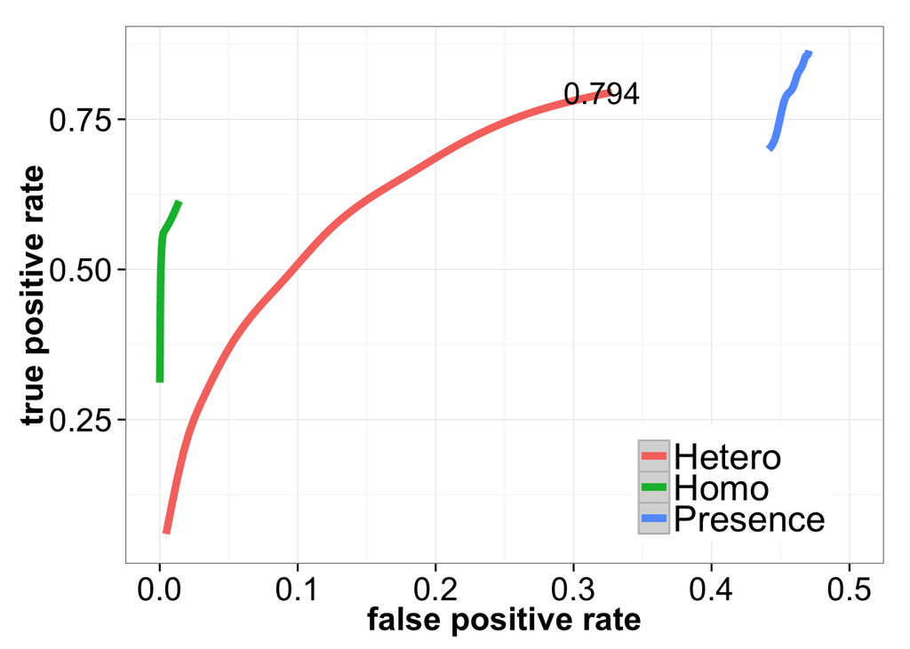

```r
####
# Set up a data.frame to plot all this complex data
####

rateTable<-rbind(cbind(melt(ratesHetTP), "type"=rep("Hetero TP rate"),"group"=rep("TP")),
cbind(melt(ratesHetFP), "type"=rep("Hetero"),"group"=rep("FP")),
cbind(melt(ratesHomoTP), "type"=rep("Homo"),"group"=rep("TP")),
cbind(melt(ratesHomoFP), "type"=rep("Homo"),"group"=rep("FP")),
cbind(melt(presenceTP), "type"=rep("Presence"),"group"=rep("TP")),
cbind(melt(presenceFP), "type"=rep("Presence"),"group"=rep("FP")) )

ggplot(rateTable,aes(x=rateTable$value[rateTable$group=="FP"],y=rateTable$value[rateTable$group=="TP"]), factor(rateTable$type))+
  theme_bw()+
  geom_smooth(aes(colour=rateTable$type[rateTable$group=="FP"]),size=2)+
  #scale_fill_discrete("")+
  theme(axis.title=element_text(size=18,face="bold"),axis.text=element_text(size=18))+
  theme(legend.title=element_blank(), legend.position=c(0.8,0.15), legend.text=element_text(size=20))+
  xlab("false positive rate")+
  ylab("true positive rate")+
  xlim(0,0.5)+
  annotate("text",x=ratesHetFP["1","6.1"],y= ratesHetTP["1","6.1"], label=round(ratesHetTP["1","6.1"],3), size =6 )
```

```r
#simCalls<-gcNorm[,c("name","sim_CNV"), with=FALSE]
```